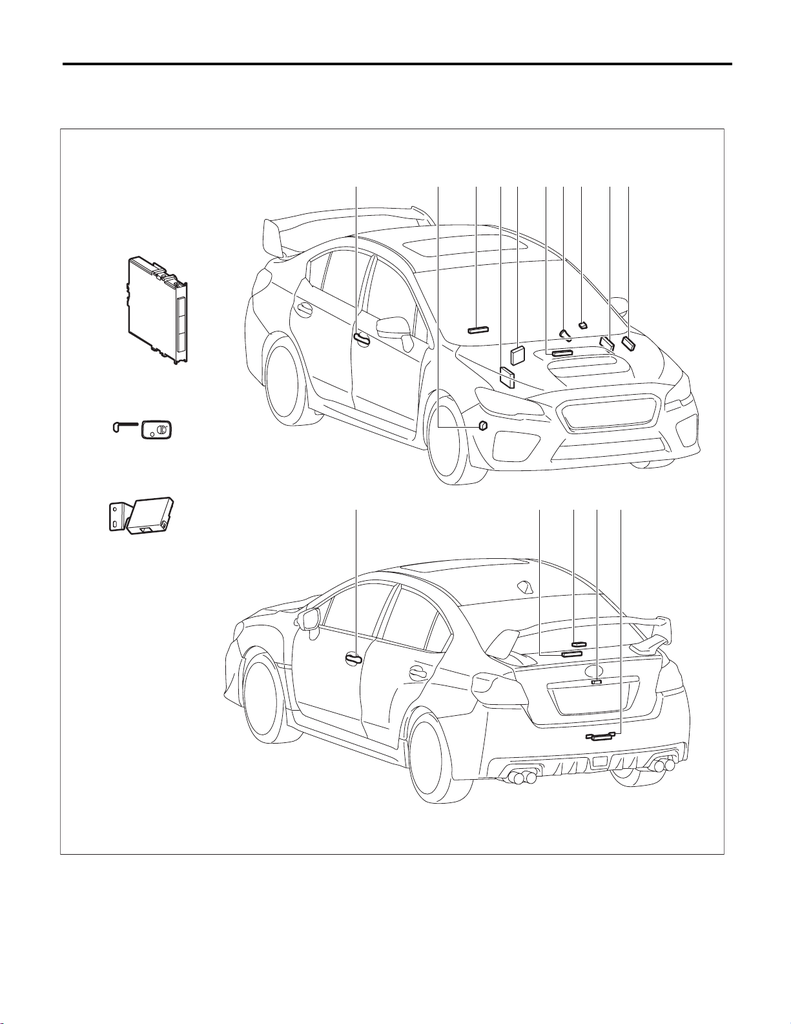

Electrical Component Location

KEYLESS ACCESS WITH PUSH BUTTON START SYSTEM (DIAGNOSTICS)

4. Electrical Component Location

A: LOCATION

SL-02819

(1)

(2)

(3)

(4)

(5)

(5) (15) (16) (17) (18)

(6) (7) (8) (9) (10)(11)(12) (13) (14)

[figure not shown]

Electrical Component Location

(1) Keyless access CM (8) ECM

(engine type FA)

(15) Rear interior antenna

(2) Mechanical key (9) ECM

(engine type EJ)

(16) Receiver

(3) Access key (10) Front interior antenna (17) Trunk opener button

(4) ID code box

(for C0 model only)

(11) Push button ignition switch (18) Rear exterior antenna

(5) Front outer handle (front exterior

antenna)

– Touch sensor (lock)

– Touch sensor (unlock)

(12) Steering lock CM

(6) Access buzzer (13) TCM

(7) Center interior antenna (14) Body integrated unit